# Cohortes de diplomation

# Cohortes de diplomation

Institut de la statistique du Québec

Personne à contacter**Aurélien Nicosia**Révision pédagogique et statistique

Année scolaire de fin de suivi d'une cohorte, avec taux par décile IMSE

Voir les résultats R[Source officielle](https://statistique.quebec.ca/fr/produit/publication/indicateurs-progres-ecart-diplomation)

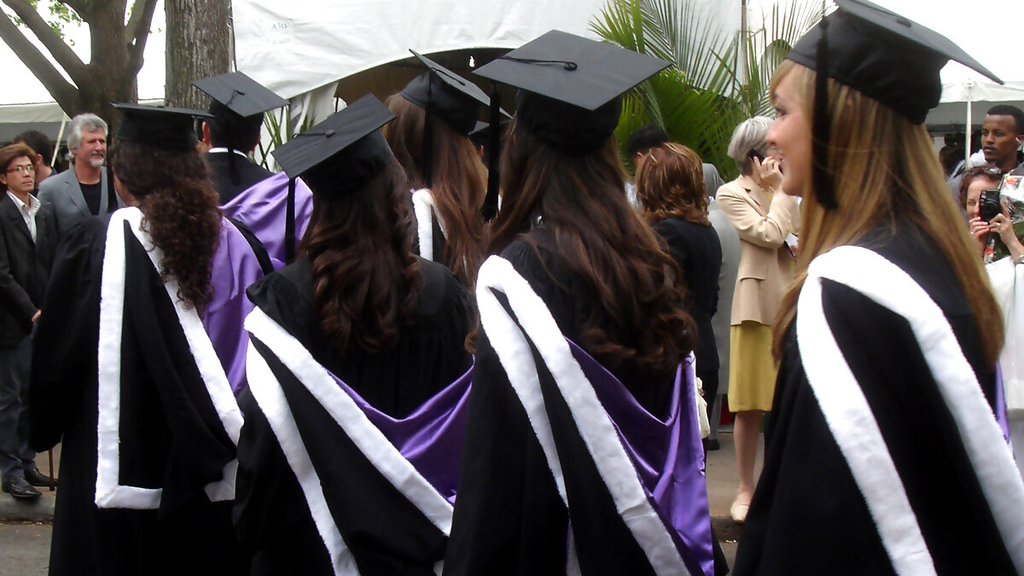

Territoire**Québec**

Niveau**Introduction**

Structure**Tableau agrégé, indicateur, temporel**

Format**XLSX téléchargeable depuis l'export du graphique ISQ**

Question de départ

Comparer les taux de diplomation des élèves des déciles IMSE 1 et 10.

Potentiel pédagogique**25 / 30**

éducationQuébecdonnées publiquesvisualisationséries temporellesstatistiques descriptivespolitiques publiques

R en action

## Aperçu reproductible

Aperçu léger calculé par R à partir des métadonnées vérifiées afin de garder la fiche rapide et stable au rendu.

Code minimal

```r
library(yaml)

metadata <- yaml::read_yaml("datasets/cohortes-diplomation/metadata.yml")
data.frame(
  champ = c("theme", "territoire", "unite", "niveau"),
  valeur = c(metadata$theme, metadata$geography, metadata$unit, metadata$level)
)
```

Résultats R

Lignes déclarées**13 années scolaires de fin de suivi dans la table préparée; 30 lignes dans l'export XLSX incluant titres, notes et source**

Colonnes déclarées**5 colonnes dans la table préparée; 4 colonnes de données dans l'export XLSX**

Format**XLSX téléchargeable depuis l'export du graphique ISQ**

Aperçu**Métadonnées**

[output not shown]

Lecture statistique

Mini-projets

- Comparer les taux de diplomation des élèves des déciles IMSE 1 et 10.
- Visualiser l'évolution de l'écart en points de pourcentage.
- Discuter les limites d'un indicateur agrégé fondé sur le lieu de résidence.

Activités liées

30-45 minutes**Comparer des taux de diplomation selon l'IMSE**

Comment comparer correctement deux taux de diplomation agrégés?

2-3 heures**Tendances de diplomation selon l'IMSE**

Comment l'écart de diplomation évolue-t-il, et quelles limites faut-il expliciter?

## Pourquoi ce jeu est intéressant

Ce jeu de données permet d’étudier un indicateur public d’inégalités scolaires : l’écart entre le taux de diplomation et de qualification après sept ans des élèves associés au décile 1 de l’IMSE et celui des élèves associés au décile 10. Il est bien adapté à une première activité de statistique descriptive, parce qu’il combine des taux, un écart en points de pourcentage, une série temporelle courte et une question d’interprétation sociale.

La fiche doit être utilisée comme une étude de cas descriptive. Les données ne décrivent pas des élèves individuels. Elles ne permettent pas non plus d’attribuer causalement un écart de diplomation au milieu socioéconomique. L’intérêt pédagogique vient précisément de cette tension : le jeu est simple à visualiser, mais demande une communication statistique prudente.

## Ce qui a été vérifié

| Élément vérifié | Résultat |
| --- | --- |
| Page officielle | Page ISQ “Écart de diplomation selon le milieu socio-économique”, consultée le 2026-06-20 |
| Export de données | Export XLSX du graphique ISQ, consulté le 2026-06-20 |
| Période couverte | 2011-2012 à 2023-2024 |
| Valeur récente publiée | 24,9 points de pourcentage en 2023-2024 |
| Cohérence interne | L’écart publié correspond au taux du décile IMSE 1 moins le taux du décile IMSE 10, à l’arrondissement près |
| Notes méthodologiques | L’IMSE est attribué selon le lieu de résidence au moment de la première inscription au secondaire |
| Conditions de reproduction | La reproduction de l’information du site de l’ISQ est interdite sauf permission écrite |

## Source et conditions

| Champ | Information |
| --- | --- |
| Source | Institut de la statistique du Québec |
| Page officielle | https://statistique.quebec.ca/fr/produit/publication/indicateurs-progres-ecart-diplomation |
| Export de données | https://statistique.quebec.ca/api/fr/produit/graphique/ecart-diplomation-selon-milieu-socio-economique/export |
| Source statistique indiquée dans l’export | Ministère de l’Éducation du Québec |
| Territoire | Québec |
| Dernière mise à jour indiquée par l’ISQ | 21 août 2025 |
| Fréquence de mise à jour | Annuelle |
| Conditions de reproduction | https://statistique.quebec.ca/fr/institut/nous-joindre/droits-auteur-permission-reproduction |
| Redistribution locale | Le CSV préparé sert aux vérifications et aux activités locales; il n’est pas intégré au rendu public de la fiche. |
| Date d’accès de cette fiche | 2026-06-20 |

## Définition de l’indicateur

L’indicateur mesure la différence entre deux taux de diplomation et de qualification après sept ans :

1. le taux des élèves dont le lieu de résidence était associé au décile 1 de l’IMSE au moment de la première inscription au secondaire;
2. le taux des élèves dont le lieu de résidence était associé au décile 10 de l’IMSE au même moment.

Le décile 1 correspond au milieu le plus favorisé dans la définition utilisée par l’ISQ, tandis que le décile 10 correspond au milieu le plus défavorisé. L’écart est exprimé en points de pourcentage.

## Ce que représente une ligne

Une ligne de la table préparée représente une année scolaire de fin de suivi d’une cohorte. Par exemple, la cohorte formée en 2005-2006 est suivie jusqu’en 2011-2012, et la cohorte formée en 2017-2018 est suivie jusqu’en 2023-2024.

La table préparée n’est pas une base de microdonnées. Elle contient 13 observations agrégées. Elle sert donc à lire une tendance et à apprendre à formuler une conclusion descriptive limitée.

## Variables principales

| Variable | Type | Description | Exemple | Point de vigilance |
| --- | --- | --- | --- | --- |
| `cohorte_entree_secondaire` | caractère | Cohorte d’entrée au secondaire, déduite de l’année de fin de suivi | `2017-2018` | Variable reconstruite dans le script de préparation |
| `annee_scolaire_fin_suivi` | caractère | Année scolaire à la fin du suivi de sept ans | `2023-2024` | Sert d’axe temporel |
| `taux_diplomation_decile_imse_1` | numérique | Taux de diplomation et qualification du décile IMSE 1 | `88.8` | Décile le plus favorisé |
| `taux_diplomation_decile_imse_10` | numérique | Taux de diplomation et qualification du décile IMSE 10 | `63.9` | Décile le plus défavorisé |
| `ecart_points_pourcentage` | numérique | Écart entre les deux taux | `24.9` | À interpréter en points de pourcentage, pas en pourcentage relatif |

## Taille et structure

| Élément | Information |
| --- | --- |
| Table préparée | 13 lignes et 5 colonnes |
| Export XLSX brut | 30 lignes, incluant titres, notes méthodologiques et source |
| Structure | Série temporelle agrégée |
| Format brut | XLSX téléchargé depuis l’export du graphique ISQ |
| Format préparé local | CSV ignoré par Git dans `data/processed/cohortes-diplomation/` |
| Niveau pédagogique recommandé | Introduction |

## Lecture statistique

La lecture statistique minimale consiste à comparer deux séries de taux, puis à analyser l’écart. La variable centrale est `ecart_points_pourcentage`, car elle résume la différence entre les deux déciles extrêmes.

Une bonne interprétation doit respecter trois contraintes :

- ne pas confondre point de pourcentage et pourcentage relatif;
- ne pas transformer un indicateur agrégé en diagnostic individuel;
- ne pas tirer de conclusion causale à partir d’une série de 13 observations agrégées.

## Score zéro déchet

| Dimension | Score | Justification |
| --- | --- | --- |
| Contexte québécois | 3 | Le jeu porte sur l’éducation au Québec. |
| Accessibilité pédagogique | 3 | Les variables principales sont simples : deux taux et un écart. |
| Qualité documentaire | 3 | La page officielle fournit la définition, la méthode, les limites et la date de mise à jour. |
| Potentiel de nettoyage | 2 | L’export contient des titres et notes à exclure, mais la table utile est courte. |
| Potentiel de visualisation | 3 | Les deux taux et l’écart se visualisent directement. |
| Potentiel de statistique descriptive | 3 | La comparaison de groupes est immédiate. |
| Potentiel d’inférence | 1 | L’inférence est très limitée par le caractère agrégé et le faible nombre d’observations. |
| Potentiel de modélisation | 1 | Une tendance peut être explorée, mais pas modélisée sérieusement sans contexte additionnel. |
| Potentiel de discussion éthique | 3 | Le jeu soulève des enjeux d’équité, de territoire et de communication responsable. |
| Réutilisabilité dans plusieurs cours | 3 | Le jeu peut servir en statistique descriptive, visualisation et communication. |

Total : 25 sur 30.

## Activité courte

En 30 à 45 minutes, demander aux personnes étudiantes de lire trois années scolaires, de comparer les deux taux et de formuler une phrase descriptive sur l’écart. L’objectif n’est pas de produire un modèle, mais de distinguer correctement un taux, un écart en points de pourcentage et une conclusion prudente.

## Activité longue

En 2 à 3 heures, demander de produire un mini-rapport avec deux graphiques : un graphique des deux taux et un graphique de l’écart. Le rapport doit inclure une section explicite sur les limites de l’indicateur.

## Questions pédagogiques possibles

1. Quelle est la différence entre un taux agrégé et une observation individuelle?
2. Pourquoi l’écart est-il exprimé en points de pourcentage?
3. Quelle information est perdue quand on compare seulement deux déciles extrêmes?
4. Pourquoi le lieu de résidence ne doit-il pas être confondu avec la situation familiale réelle?
5. Quels graphiques conviennent à une série d’années scolaires?
6. Que peut-on dire descriptivement de l’évolution de l’écart?
7. Qu’est-ce qu’on ne peut pas conclure avec ces données?
8. Comment rédiger une conclusion qui évite la causalité abusive?

## Code R minimal

```r
library(dplyr)
library(ggplot2)
library(readr)
library(readxl)
library(tidyr)

source_url <- "https://statistique.quebec.ca/api/fr/produit/graphique/ecart-diplomation-selon-milieu-socio-economique/export"
raw_path <- tempfile(fileext = ".xlsx")

download.file(source_url, raw_path, mode = "wb", quiet = TRUE)

diplomation_raw <- read_excel(raw_path, col_names = FALSE, .name_repair = "minimal")
names(diplomation_raw) <- paste0("col", seq_along(diplomation_raw))

diplomation <- diplomation_raw |>
  filter(grepl("^\\d{4}-\\d{4}$", as.character(col1))) |>
  setNames(c(
    "annee_scolaire_fin_suivi",
    "taux_diplomation_decile_imse_1",
    "taux_diplomation_decile_imse_10",
    "ecart_points_pourcentage"
  )) |>
  mutate(
    annee_debut_fin_suivi = as.integer(substr(annee_scolaire_fin_suivi, 1, 4)),
    cohorte_entree_secondaire = paste0(
      annee_debut_fin_suivi - 6,
      "-",
      annee_debut_fin_suivi - 5
    ),
    across(
      c(
        taux_diplomation_decile_imse_1,
        taux_diplomation_decile_imse_10,
        ecart_points_pourcentage
      ),
      ~ parse_number(as.character(.x), locale = locale(decimal_mark = "."))
    )
  ) |>
  select(
    cohorte_entree_secondaire,
    annee_scolaire_fin_suivi,
    taux_diplomation_decile_imse_1,
    taux_diplomation_decile_imse_10,
    ecart_points_pourcentage
  )

diplomation_long <- diplomation |>
  select(
    annee_scolaire_fin_suivi,
    taux_diplomation_decile_imse_1,
    taux_diplomation_decile_imse_10
  ) |>
  pivot_longer(
    cols = starts_with("taux_diplomation"),
    names_to = "groupe",
    values_to = "taux_diplomation"
  ) |>
  mutate(
    groupe = recode(
      groupe,
      taux_diplomation_decile_imse_1 = "Décile IMSE 1",
      taux_diplomation_decile_imse_10 = "Décile IMSE 10"
    )
  )

ggplot(
  diplomation_long,
  aes(
    x = annee_scolaire_fin_suivi,
    y = taux_diplomation,
    color = groupe,
    group = groupe
  )
) +
  geom_line() +
  geom_point() +
  labs(
    x = "Année scolaire de fin de suivi",
    y = "Taux de diplomation et qualification (%)",
    color = "Groupe",
    title = "Taux de diplomation selon deux déciles IMSE"
  )
```

## Limites et précautions

- L’indicateur compare les déciles IMSE 1 et 10; il ne résume pas toute la distribution.
- Les taux agrégés ne permettent pas de conclure au niveau individuel.
- L’IMSE est fondé sur le lieu de résidence, pas sur la situation familiale réelle.
- Les écarts observés ne suffisent pas à établir une cause.
- La série préparée contient 13 observations, ce qui limite fortement toute modélisation.
- La réutilisation du contenu ISQ doit respecter les conditions de reproduction applicables.

## Extensions

- Extension intro : comparer les deux taux pour trois années scolaires.
- Extension visualisation : représenter l’écart en points de pourcentage.
- Extension critique : comparer ce que montre un graphique des taux et ce que montre un graphique des écarts.
- Extension communication : rédiger une note courte qui distingue résultat descriptif et explication causale.